# Machine Learning with Coursera

Jae Kwan Koo

# Linear Regression with multiple variables

## Multiple features

이전까지의 예)  
집의 가격을 결정하는 feature or variable - 집의 크기

‘침실의 개수’, ’집의 나이’도 알고 있다면 가격을 결정하는 더 많은 요소를 갖고 있는 것이 된다.

### 다중선형회귀에서의 notation

Linear regression with multiple variables is also known as **“multivariate linear regression”**.

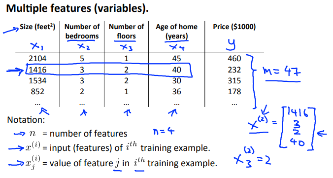

| notation | description |
| --- | --- |
| n | feature들의 수 |
| $x^{(i)}$ | training set에서의 i번째 관측치들 |
| $x^{(i)}_j$ | training set에서의 i번째 관측치들에서 j번째 feature |

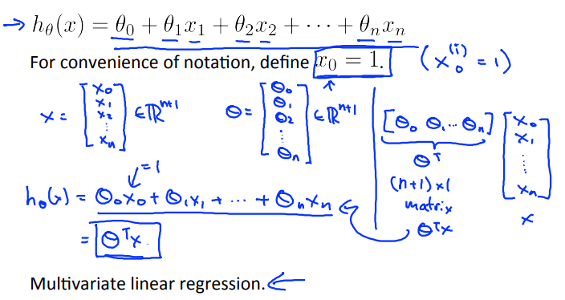

이제 가설은 이전과 달리 features(variables)갯수에 따라 더 늘어난 모습을 보인다.

notation의 편의를 위해, `x_0 =1`이라고 가정하자.  
이는 통계에서의 $\beta_0X_0$에서 $X_0=1$인 것과 같은 이치이다.

벡터의 내적에 의해 벡터표현을 사용하면 더 깔끔하다.

$$h_\theta(x) = \theta_0+\theta_1x_1+\theta_2x_2+...+\theta_nx_n$$

$$h_\theta(x) = [\theta_0,...,\theta_n]^T[X_0,...,X_n]=\theta^TX$$

#### 통계에서의 다중선형회귀

$$Y = X\beta$$

$$y_i = \beta_0+\beta_1X_{i,1}+\beta_2X_{i,2}+...+\beta_{p-1}X_{i,p-1}, i=1,...,n$$

관측치(i)가 1부터 n까지 존재한다.  
전체 beta갯수는 p개이다. 즉, nxp matrix

## Gradient descent for multiple variables

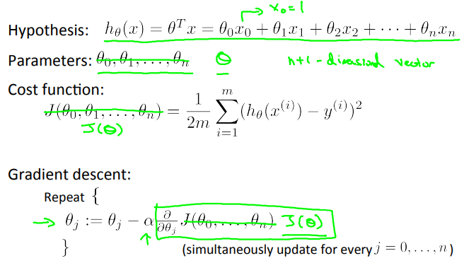

theta들을 vector로 표현해보자  
각 theta에 대해 Gradient Descent를 진행해야 한다.

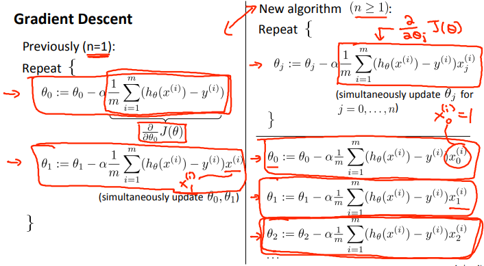

이전의 n=1, 그러니까 feature(variable)이 한 개만 있을 때는 theta0, 1에 관한 경사 하강법은 왼쪽과 같이 진행하였다.

일반화를 시켜보면 오른편처럼 적어줄 수 있을 것이다.  
사실 왼편도 생각해보면 똑같다. theta0업데이트 하는 식에 $x_0^{(i)}$를 적어주면 다를게 없다. 물론 여기서 $x_0^{(i)}$는 1이라고 가정했다.

## Gradient descent in practice 1 : Feature Scaling

We can speed up gradient descent by having each of our input values in roughly the same range.  
This is because θ will descend quickly on small ranges and slowly on large ranges, and so will oscillate inefficiently down to the optimum when the variables are very uneven.

The way to prevent this is to modify the ranges of our input variables so that they are all roughly the same.

이상적으로 [-1, +1] 또는 [-0.5, +0.5]

These aren’t exact requirements; we are only trying to speed things up.  
The goal is to get all input variables into roughly one of these ranges

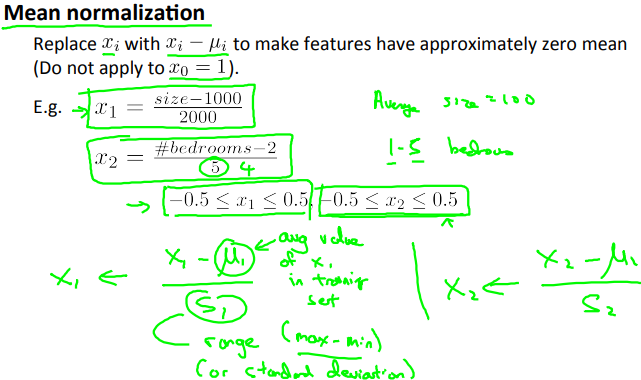

두 개의 feature가 있다고 해보자.

| Feature | range |
| --- | --- |
| x1(집 크기) | [0,2000] |
| x2(침실 수) | [0, 5] |

cost function J(θ)를 그래프로 그린다면 J(θ)는 파라미터 θ_0, θ_1, θ_2의 함수.  
θ_0는 고려하지 않고 θ1과 θ2의 함수들만 보도록 하자.  
x1의 범위가 x2보다 크다면, cost function J(θ)의 모양은 굉장히 뾰족한 타원모양이 나올 수 있다.

만약, 이 cost function에 gradient descent를 적용한다면, gradient는 오랜 시간 동안 앞 뒤로 진동하며, 엄청난 시간이 지나고 나서야 마침내 최소값에 도달할 것이다.

등고선이 극단적인 경우를 생각해보면, gradient descent는 훨씬 더 많은 시간을 소요하며, 구불구불하게 가다가, 오랜 시간이 지나서야 최소값을 찾을 수 있을 것이다.

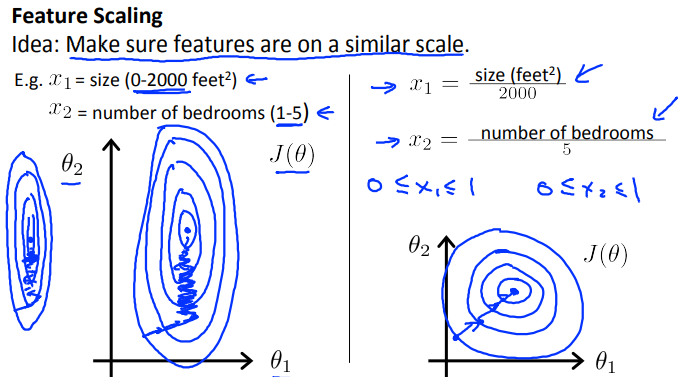

이 때, 유용한 방법이 **feature scale**하는 것

feature x1 : 집 크기를 2000으로 나눈 값(range : 2000(max)-0(min))  
x_2 : 침실의 수를 5로 나눈 값(range : 5(max)-0(min))

cost function의 모양은 훨씬 덜 뾰족한 원에 가까운 타원모양이 되어 이러한 cost function에 gradient descent를 하면은 더 빠르게 수렴하고, 똑바른 방향으로 최소값을 찾는 것을 볼 수 있다. (난해한 경로로 복잡한 궤도를 그리며 구불구불하게 가지 않는다.)

**핵심은 feature를 조절하여, 적절한 범위가 되도록 하는 것**

보통 feature scaling을 할 때, 모든 feature가 대략 -1에서 +1사이의 범위가 있으면 괜찮지만 -1과 +1은 중요하지 않다.

### case

[-1, +1]과 근사한 경우 괜찮다.

ex)  
어떤 feature 범위 : [0, 3]  
어떤 feature 범위 : [-2, 0.5]

[-1, +1]과 근사하지 않은 경우 좋은 feature가 아니다.

ex)  
[-100, +100] [-0.0001, +0.0001] - 너무 작은 값을 가질 때

이러한 경우, feature를 조절해야한다.  
사람마다 이러한 기준은 다르다. 예컨대 [-3, +3], [-1/3, +1/3] 등 보통 0근처의 범위면 상관없지만, 기준이 [-0.0001, +0.0001]처럼 너무 작다면 문제가 된다.

## Mean normalization

$$X = {x_i-mean(x)\over max(x)-min(x)}$$

평균을 빼고 범위로 나눠준다.

아마이 것은 근사적으로 [-0.5, +0.5]의 값을 가질 것이다.  
feature scaling은 너무 정확할 필요는 없는게 gradient descent가 훨씬 더 빨라지면 그만이다.

정리하자면, `feature scaling`과 `mean normalization`이 feature들의 범위를 거의 같게 맞춰줄 수 있는 방법 중 하나이다.

feature scaling - 값을 범위로 나누게 된다. 거의 -1과 1사이의 값을 가지게 된다.  
mean normalizition - 값에 평균을 빼고 범위로 나눈다. 거의 -0.5와 0.5사이의 값을 가지게 된다.

## Gradient descent in practice 2 : Learning rate

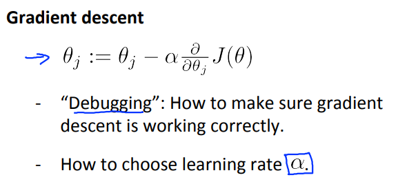

이번에 하고자 하는 것은 **debugging**이다.

- debugging : gradient descent가 잘 돌아가게 하기 위한 방법
- how to choose alpha? - 어떤 값으로 시작할지에 대한 것

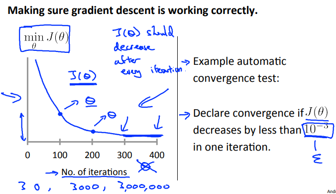

잘 작동하는 gradient descent는 반복할 때마다 cost function이 매번 감소해야 한다. 그리고 이후 평평한 것처럼 보이는 지점 이후에는 수렴한 것이다. cost function이 더 이상 줄어들지 않기 때문이다.

gradient descent가 수렴하는데 필요한 반복횟수는 경우에 따라 다르다.  
사전에 알기 힘들며, 반복 횟수 대 cost function의 그래프를 통해 수렴여부를 확인한다. (물론 자동으로 검사하는 automatic convergence test도 있다.)

cost function의 감소량이 어떤 작은 값보다 작아졌을 때, 수렴했다라고 판단한다.

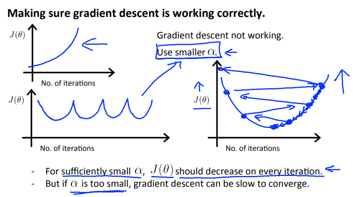

cost function이 증가하는 경우는 더 작은 learning rate를 사용해야 한다는 것을 알 수 있다.

내려가다 올라가는 반복하는 경우에도 작은 alpha를 사용하자.  
물론 너무 작은 alpha로 인해 너무 천천히 수렴하게 하는 일도 피하는게 좋다.

alpha는 경험적으로 조금씩 변화시켜가며 알맞은 값을 찾아보자.

## Features and polynomial regression

집의 frontage와 depth이라는 features가 있다고 하자.

frontage : 너비 즉 집 폭의 길이  
depth : 집의 세로길이

$$h_\theta{(x)} = \theta_0+\theta_1 X_1+\theta_2X_2$$

이제는 직접 새로운 feature(집의 크기)를 만들어보자.

$$h_\theta{(x)} = \theta_0+\theta_1X$$

x :frontage x depth

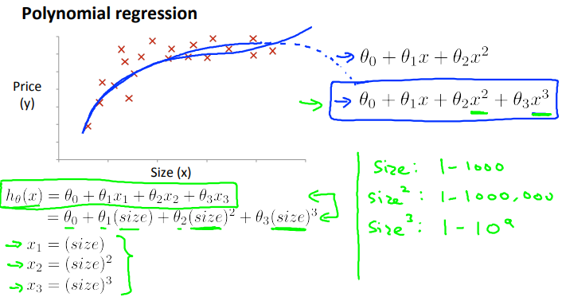

이 데이터를 설명할 수 있는 모형들은 여러가지가 있을 것이다.  
polynomial의 degree에 따라 quadratic, cubic, quartic, quintic… 등 이름이 불린다.

2차식(quadratic) : 나중에 감소하는 형식의 그래프이기 때문에 적절하지 않다.  
3차식(cubic) : 감소하지 않기 때문에 2차식보다는 적절하다.

감소한다면 집의 크기가 증가할 때, 가격이 떨어지는 것으로 예측되기 때문에 2차식은 적절하지 않다는 것

**feature들의 제곱이나 세제곱을 하게되면 범위가 feature마다 매우 달라지기 때문에 feature scaling이 매우 중요해진다.**

3차식말고도 제곱근의 형태로 나타내는 방법도 있다.  
제곱근의 함수를 생각해본다면 어떤 지점까지 평평해지지 감소하지는 않는 개형이다.

$$h_\theta{(x)} = \theta_0+\theta_1X+\theta_2\sqrt{X}$$

## Normal equation

normal equation은 theta를 분석적으로 구하는 방법이다. 그래서 여러번 알고리즘을 돌릴 필용 없이, theta의 최적의 값을 한 번에 구한다.

각 theta에 대해 모두 각각 편미분하여 0이되게 하는 식을 풀면 되지만, 행렬의 형태로 해결하는 것이 더 수월하다.

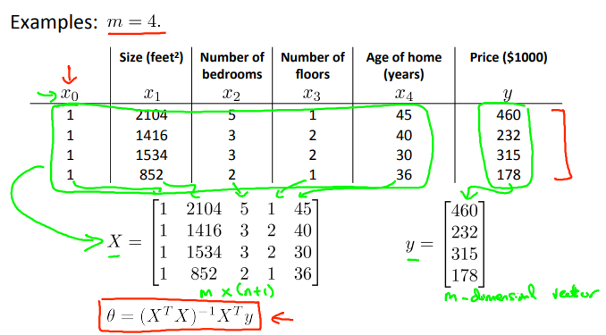

### comparison of gradient descent and the normal equation

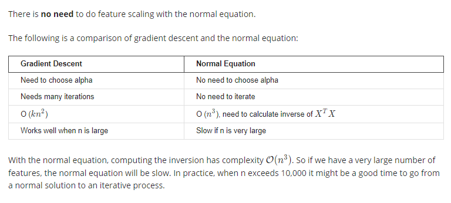

## Normal equation and non-invertibility(optional)

The generalized inverse (or pseudo inverse) 는 R에서 pinv()함수로 계산할 수 있다. $X^tX$가 역행렬이 존재하지 않아도 구할 수 있게 된다.

만약 $X^tX$가 singular이면 불필요한 feature를 지워 선형독립이 되게 맞춰준다. full rank이면 역행렬이 존재하게 된다.

너무 많은 feature들이 있으면 몇몇 feature들을 지우거나 regularization을 사용한다. regularization부분은 나중에 알아보도록 하자.

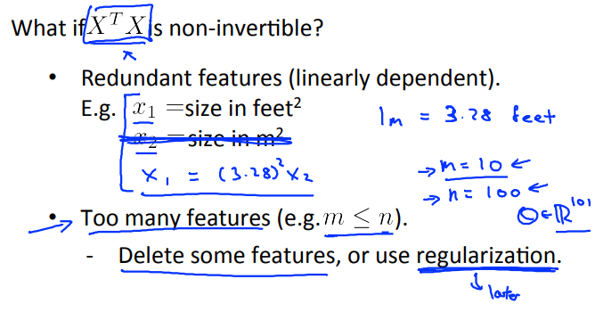

## Test question

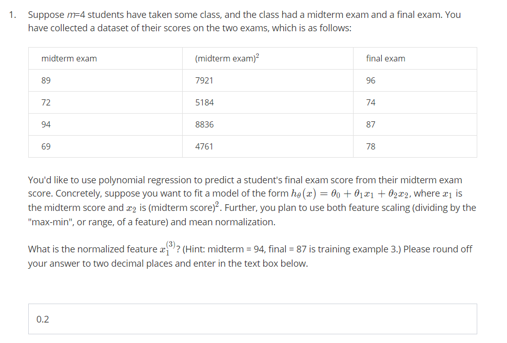

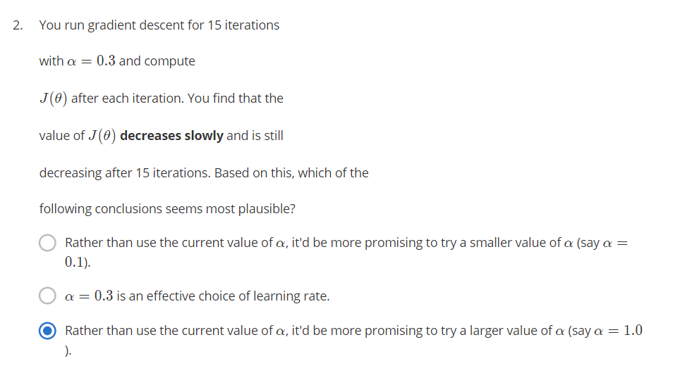

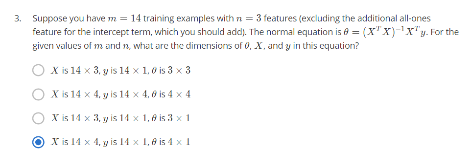

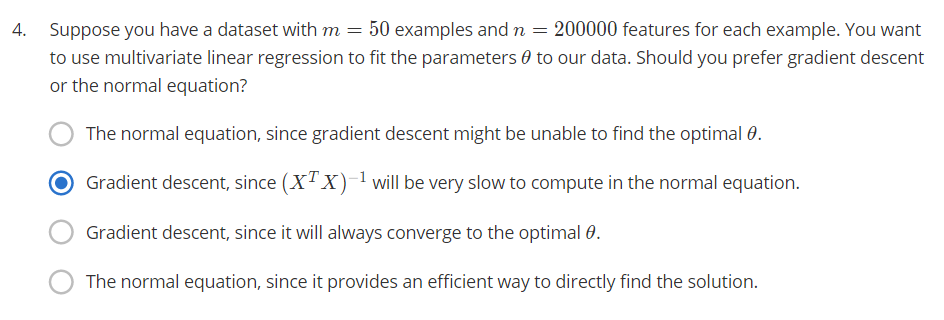

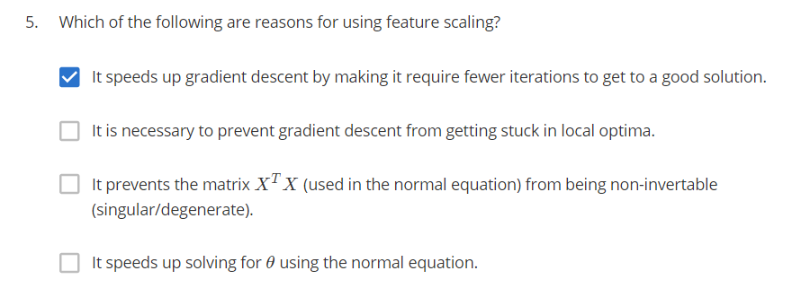

## Exercise

### Data

```r
data1 <- read.table("ex1data1.txt", sep=",")
data2 <- read.table("ex1data2.txt", sep=",")

head(data1)
```

```
##       V1      V2
## 1 6.1101 17.5920
## 2 5.5277  9.1302
## 3 8.5186 13.6620
## 4 7.0032 11.8540
## 5 5.8598  6.8233
## 6 8.3829 11.8860
```

```r
head(data2)
```

```
##     V1 V2     V3
## 1 2104  3 399900
## 2 1600  3 329900
## 3 2400  3 369000
## 4 1416  2 232000
## 5 3000  4 539900
## 6 1985  4 299900
```

### A = WARMUPEXERCISE() is an example function that returns the 5x5 identity matrix

```r
A <- function(x) {
  diag(x)
  }

WARMUPEXERCISE <- A(5)

WARMUPEXERCISE
```

```
##      [,1] [,2] [,3] [,4] [,5]
## [1,]    1    0    0    0    0
## [2,]    0    1    0    0    0
## [3,]    0    0    1    0    0
## [4,]    0    0    0    1    0
## [5,]    0    0    0    0    1
```

### Gradient descent

```r
x <- data1[,1]
y <- data1[,2]

computeCost <- function(X, y, theta){
  sum((X%*%theta-y)^2) / (2*length(y))
  }


# learning rate
alpha <- 0.01

# initialize coefficients
theta <- matrix(c(2,2), nrow=2)

# add a column of 1's for the intercept coefficient
X <- cbind(1, as.matrix(x))


cost_history <- rep(0,5000)
theta_history <- list(0)
temp <- rep(0,5000)
i <- 1
# gradient descent
while (T) {
  error <- X %*% theta - y
  theta <- theta - alpha * (t(X) %*% as.matrix(error) / length(y))
  cost_history[i] <- computeCost(X, y, theta)
  theta_history[[i]] <- theta

  if(i>=2){
    temp[i] <- abs(cost_history[i]-cost_history[i-1])
    if(abs(temp[i])<10^(-7)) break;
  }

  i <- i+1
  if(i>5000) break;
}
```

```r
temp[(i-10):i]
```

```
##  [1] 1.035198e-07 1.031469e-07 1.027754e-07 1.024052e-07 1.020363e-07
##  [6] 1.016688e-07 1.013026e-07 1.009377e-07 1.005741e-07 1.002119e-07
## [11] 9.985091e-08
```

```r
cost_history[[i-1]]
```

```
## [1] 4.476999
```

```r
theta_history[[i-1]]
```

```
##           [,1]
## [1,] -3.878331
## [2,]  1.191281
```

각각 tolerance, cost값, 선형 회귀의 coefficients이다.

```r
fit <- lm(y~x)
fit$coefficients
```

```
## (Intercept)           x
##   -3.895781    1.193034
```

최소제곱법의 normal equation으로 구한 값과 비슷하다. iteration을 늘렸다면 값이 동일하게 나올 것이다.

### Normal Equation

```r
solve(t(X) %*% X) %*% t(X) %*% y
```

```
##           [,1]
## [1,] -3.895781
## [2,]  1.193034
```

위와 동일한 값이다.

### Feature Scaling

```r
featureNormalize <- function(X_norm){
  mu <- colMeans(X_norm)
  sigma <- apply(X_norm,2,function(x) sd(x))

  new_dat <- matrix(ncol = ncol(X_norm), nrow = nrow(X_norm))

  for(i in 1:ncol(new_dat)){
    new_dat[,i] <- (X_norm[,i]-mu[i])/sigma[i]
  }
  return(new_dat)

}

featureNormalize(data2)
```

```
##                [,1]       [,2]        [,3]
##  [1,]  0.1300098691 -0.2236752  0.47574687
##  [2,] -0.5041898382 -0.2236752 -0.08407444
##  [3,]  0.5024763638 -0.2236752  0.22862575
##  [4,] -0.7357230647 -1.5377669 -0.86702453
##  [5,]  1.2574760154  1.0904165  1.59538948
##  [6,] -0.0197317285  1.0904165 -0.32399786
##  [7,] -0.5872397999 -0.2236752 -0.20403615
##  [8,] -0.7218814044 -0.2236752 -1.13094828
##  [9,] -0.7810230438 -0.2236752 -1.02697347
## [10,] -0.6375731100 -0.2236752 -0.78305133
## [11,] -0.0763567023  1.0904165 -0.80305294
## [12,] -0.0008567372 -0.2236752  0.05268191
## [13,] -0.1392733400 -0.2236752 -0.08328269
## [14,]  3.1172918237  2.4045083  2.87498104
```

[output cut: 33 more lines]

data를 받아 각 컬럼별로 컬럼의 평균을 빼고 컬럼의 표준편차를 각 컬럼에 대해 적용하는 사용자 정의 함수를 만들었다.

```r
scale(data2, center = T, scale = T)
```

```
##                  V1         V2          V3
##  [1,]  0.1300098691 -0.2236752  0.47574687
##  [2,] -0.5041898382 -0.2236752 -0.08407444
##  [3,]  0.5024763638 -0.2236752  0.22862575
##  [4,] -0.7357230647 -1.5377669 -0.86702453
##  [5,]  1.2574760154  1.0904165  1.59538948
##  [6,] -0.0197317285  1.0904165 -0.32399786
##  [7,] -0.5872397999 -0.2236752 -0.20403615
##  [8,] -0.7218814044 -0.2236752 -1.13094828
##  [9,] -0.7810230438 -0.2236752 -1.02697347
## [10,] -0.6375731100 -0.2236752 -0.78305133
## [11,] -0.0763567023  1.0904165 -0.80305294
## [12,] -0.0008567372 -0.2236752  0.05268191
## [13,] -0.1392733400 -0.2236752 -0.08328269
## [14,]  3.1172918237  2.4045083  2.87498104
```

[output cut: 39 more lines]

물론 scale기본함수 하나면 끝난다.